# Rを使ったデータ分析入門

上ノ原 秀晃

2025-12-16

この資料は上ノ原が自分の授業で使用するために作成しているものです。

## 1 Rの特徴

この資料では統計ソフトRを使ったデータ分析について説明しています。Rは統計分析ソフトの一つで、さまざまな分野の研究や実務において利用されています。

Rの特徴は、まず無料で利用できることです。SPSSなどの統計ソフトは、安いもので数万円、高いものは数十万円かかります。それゆえ、大学でこのようなソフトの使用方法を学んでも、卒業後に使うことはまずありません。一方、Rは無料ですので、個人のPC（や許可が得られれば会社のPC）にインストールしてデータ分析を行うことができます。

Rのもう一つの特徴は、さまざまな追加機能がオプション（パッケージといいます）で追加されていることです。Rの本体は必ずしも多機能とは言えないのですが、世界中の研究者やプログラマなどがデータの加工や分析に有益なさまざまなパッケージを公開しています。Rの利用者はとても多いので、先進的な分析手法が他の有料ソフトに先立って利用可能になることも珍しくありません。

以上のような理由で、従来SPSSが主流であった社会学や心理学の分野においても、Rの利用が増加しています。。大学の授業についても同様で、Rを用いた社会調査や心理統計のテキストも徐々に刊行されています。

一方、Rにも短所はあります。第1の短所は、使い方が難しいことです。例えばSPSSではマウスを使った操作でデータの分析や加工を行うことができます（これをGUI=Graphical User Interfaceといいます）。一方、Rではキーボードからコマンドを入力する必要があります（これをCUI=Character User Interfaceといいます）。初歩的なプログラムミングの経験があればそれほど難しくありませんが、ない場合はハードルが高く感じられるでしょう。

第2の短所は、とても残念なことですが、社会調査のデータ分析はあまり得意ではないことです。SPSSにあるような、特定の（複数の）値を欠損値として扱う機能はRにはありません。パッケージとしても提供されていないようです。また、質問紙調査の後には度数分布表やクロス集計表で回答の分布や質問間の関連を確認しますが、Rでは度数と相対度数（％）を同時に表示することができません。とはいえ、いずれの欠点も分析方法を工夫したり、出力結果を加工することで対処可能ですので、あまり致命的な問題点とはいえません。

なお、以下の説明では、ブラウザ内で使用できるPosit Cloudを使用します。Posit CloudはRStudioのクラウド版です。RStudioは統合開発環境（IDE: Integrated Development Environment）と呼ばれるソフトウェアで、Rを便利に利用するためのさまざまな機能を有しています。

## 3 Rを使ってみる

### 3.1 計算

まずRStudioを起動します。右側のConsoleという枠の`>`の後にコマンドを入力します。

まずは簡単な計算から。`1+1`と入力してみましょう。`+`の前後の空白はあってもなくても構いません。

```r
1 + 1
```

```
## [1] 2
```

他にも四則演算を行ってみましょう。掛け算記号は`*`、割り算記号は`/`を使います（Excelなどと共通するルールです）。

```r
5 - 3
```

```
## [1] 2
```

```r
3 * 4
```

```
## [1] 12
```

```r
8 / 2
```

```
## [1] 4
```

もう少し複雑な計算も可能です。

```r
4 + 3 * 7
```

```
## [1] 25
```

```r
(4 + 3) * 7
```

```
## [1] 49
```

```r
3 ^ 2
```

```
## [1] 9
```

```r
3 ^ 3
```

```
## [1] 27
```

```r
3 ^ (1/2)
```

```
## [1] 1.732051
```

最後の`3 ^ (1/2)`は3の2分の1乗を示しています。2分の1乗は平方根と同じですから、答えは$\sqrt{3} = 1.732 \cdots$になります。`1/2`にカッコがついているのは、`3 ^ 1 / 2`（3の1乗 割る2）と区別するためです。

### 3.2 オブジェクト

上の例では3の2乗、3乗、2分の1乗を計算しました。このように、同じ数字を繰り返し用いる場合には、オブジェクトを利用することができます。オブジェクトは数学の文字式におけるx、yのような文字のようなもので、数字を代入することができます。代入は`<-`という記号で表します。

```r
x <- 3
x ^ 2
```

```
## [1] 9
```

```r
x ^ 3
```

```
## [1] 27
```

```r
x ^ (1/2)
```

```
## [1] 1.732051
```

オブジェクトを使った計算をいくつか行ってみましょう。

```r
x <- 3
y <- 4
x*y
```

```
## [1] 12
```

```r
x <- x + 1
x
```

```
## [1] 4
```

`x <- x + 1`は「xに1を足した数字をxに代入する」という意味です。

なお、オブジェクトの名前は一文字とは限りません。（あまりお勧めしませんが）日本語も使うことができます。（RStudioのバージョンによってはUnexpected Tokenという警告が出ることがありますが、無視して構いません。）

```r
身長 <- 173
体重 <- 69
BMI <- 体重 / (身長/100)^2
BMI
```

```
## [1] 23.05456
```

オブジェクトには文字列も代入することができます。文字列を代入する場合は、文字列はダブルクオテーション`"`で囲みます。

```r
name <- "大谷翔平"
paste("私の名前は",name,"です")
```

```
## [1] "私の名前は 大谷翔平 です"
```

上の例の2行目では、pasteという関数を使って、「私の名前は」「大谷翔平」=（nameの中身）「です」の3つの文字列を繋げています（copy & pasteのpasteです）。nameの中身を自分の名前に変えて試してみてくだい。

### 3.3 論理式

次に論理式というものを学びます。論理式はその内容が真か偽かを判断し、真の場合にはTRUE、偽の場合にはFALSEの値を返すものです。aとbが等しいかどうかを判断する場合は、等号は`=`ではなく`==`を用いて`a == b`と書きます。その他、大小記号も使って、値の大小を判断することができます。なお、論理式の真偽を判断することを、「式を評価する」ともいいます。以下で例を見てみましょう。

```r
1 == 1
```

```
## [1] TRUE
```

```r
2 == 3
```

```
## [1] FALSE
```

```r
4 > 3
```

```
## [1] TRUE
```

```r
4 >= 3
```

```
## [1] TRUE
```

```r
3 >= 3
```

```
## [1] TRUE
```

```r
4 < 3
```

```
## [1] FALSE
```

4つ目と5つ目の`>=`は$\geqq$を示しています。結果がTRUEなのは不思議に思うかもしれません。 しかし、$a \geqq b$は「aはbより大きい、または、bと等しい」という意味ですから、$4 \geqq 3$は真になります。同様に、$3 \geqq 3$も真です。

論理式では、文字列も比較することができます。等号で比較した場合は、前後の文字列が完全に一致していればTRUE、そうでなければFALSEになります。大小記号を使って比較するした場合は、アルファベット順、（ひらがな、カタカナ同士の場合は）あいうえお順、または文字コード順で比較します。下の例ではDodgersのDはAngelsのAよりもアルファベットで後に来ますから、`"Dodgers" > "Angels"`はTRUEになります。（球団の強さを比較しているわけではありません）

```r
name == "デコピン"
```

```
## [1] FALSE
```

```r
"Dodgers" > "Angels"
```

```
## [1] TRUE
```

### 3.4 ベクトル

ベクトルに含まれているデータの数をベクトルの長さ、もしくはベクトルのサイズといいます。 ベクトルの順序には意味があり、下の例では5人の身長、体重、名前が同じ順序で入っています。 このとき、ベクトルの長さ（サイズ）は5です。

```r
height <- c(176, 173, 168, 166, 170)
weight <- c(58, 62, 52, 54, 55)
name <- c("相葉","松本","二宮","大野","櫻井")
height
```

```
## [1] 176 173 168 166 170
```

```r
weight
```

```
## [1] 58 62 52 54 55
```

```r
name
```

```
## [1] "相葉" "松本" "二宮" "大野" "櫻井"
```

数字のベクトルにある値を加減乗除すると、ベクトルのすべての値に対してその計算を行う。一方、ベクトル同士で加減乗除すると、ベクトルの同じ位置の数字同士で計算を行う。そのため、同じ長さのベクトル同士でしか計算を行うことはできない。（厳密にいえば違うのだが、ひとまずそのように考えて差し支えない）

```r
height / 100
```

```
## [1] 1.76 1.73 1.68 1.66 1.70
```

```r
height - weight
```

```
## [1] 118 111 116 112 115
```

ベクトルに対して論理式を適用することもできます。

```r
height >= 170
```

```
## [1]  TRUE  TRUE FALSE FALSE  TRUE
```

```r
name == "二宮"
```

```
## [1] FALSE FALSE  TRUE FALSE FALSE
```

```r
height >= c(180, 175, 170, 165, 160)
```

```
## [1] FALSE FALSE FALSE  TRUE  TRUE
```

### 3.5 データフレーム

これまではベクトル単位でデータを扱ってきましたが、他の統計分析ソフトと同様、表形式のデータを扱うことができます。Rでは表形式のデータをデータフレームという形式で扱います。

ベクトルをdata.frame()関数でまとめるとデータフレームになります。

```r
arashi <- data.frame(name,height,weight)
arashi
```

```
##   name height weight
## 1 相葉    176     58
## 2 松本    173     62
## 3 二宮    168     52
## 4 大野    166     54
## 5 櫻井    170     55
```

```r
head(arashi)
```

```
##   name height weight
## 1 相葉    176     58
## 2 松本    173     62
## 3 二宮    168     52
## 4 大野    166     54
## 5 櫻井    170     55
```

```r
summary(arashi)
```

```
##      name               height          weight
##  Length:5           Min.   :166.0   Min.   :52.0
##  Class :character   1st Qu.:168.0   1st Qu.:54.0
##  Mode  :character   Median :170.0   Median :55.0
##                     Mean   :170.6   Mean   :56.2
##                     3rd Qu.:173.0   3rd Qu.:58.0
##                     Max.   :176.0   Max.   :62.0
```

```r
arashi$height
```

```
## [1] 176 173 168 166 170
```

```r
arashi$dif <- arashi$height - arashi$weight # データフレームに含まれる列
dif <- arashi$height - arashi$weight # データフレームから独立したベクトル
```

```r
arashi[5,2] # 5行2列目（櫻井の身長）
```

```
## [1] 170
```

```r
arashi[5,"height"] # 5行目のheight列（櫻井の身長）
```

```
## [1] 170
```

```r
arashi[5,c("height","weight")]
```

```
##   height weight
## 5    170     55
```

```r
arashi[c(4,5),"height"]
```

```
## [1] 166 170
```

```r
arashi$height[2]
```

```
## [1] 173
```

```r
arashi[5,]
```

```
##   name height weight dif
## 5 櫻井    170     55 115
```

```r
arashi[,2]
```

```
## [1] 176 173 168 166 170
```

```r
over170 <- arashi$height >= 170
arashi$name[over170]
```

```
## [1] "相葉" "松本" "櫻井"
```

```r
arashi$name[arashi$height >= 170]
```

```
## [1] "相葉" "松本" "櫻井"
```

```r
name <- c("相葉", "松本", "二宮", "大野", "櫻井", "中居", "木村", "稲垣", "草なぎ", "香取")
group <- c("arashi", "arashi", "arashi", "arashi", "arashi", "smap", "smap", "smap", "smap", "smap")
height <- c(176,173,168,166,170,165,176,172,170,183)
weight <- c(58, 62, 52, 54, 55, 57, 57, 54, 55, 78)
idol <- data.frame(name,group,height,weight)
idol
```

```
##      name  group height weight
## 1    相葉 arashi    176     58
## 2    松本 arashi    173     62
## 3    二宮 arashi    168     52
## 4    大野 arashi    166     54
## 5    櫻井 arashi    170     55
## 6    中居   smap    165     57
## 7    木村   smap    176     57
## 8    稲垣   smap    172     54
## 9  草なぎ   smap    170     55
## 10   香取   smap    183     78
```

```r
mean(idol$height)
```

```
## [1] 171.9
```

```r
mean(idol$weight)
```

```
## [1] 58.2
```

```r
mean(idol$height[idol$group=="smap"])
```

```
## [1] 173.2
```

```r
mean(idol$height[idol$group=="arashi"])
```

```
## [1] 170.6
```

```r
t.test(height ~ group, data = idol)
```

```
##
##  Welch Two Sample t-test
##
## data:  height by group
## t = -0.74135, df = 6.4706, p-value = 0.4845
## alternative hypothesis: true difference in means between group arashi and group smap is not equal to 0
## 95 percent confidence interval:
##  -11.032619   5.832619
## sample estimates:
## mean in group arashi   mean in group smap
##                170.6                173.2
```

## 4 データの基本的分析

```r
# install.packages("tidyverse", dependencies = TRUE)
library("tidyverse")
d <- read.csv("https://www.nstac.go.jp/sys/files/SSDSE-C-2024.csv", fileEncoding = "CP932" ,skip=1)

head(d)
```

```
##   地域コード 都道府県     市 世帯人員 食料.合計. X01.穀類    米 食パン 他のパン
## 1     R00000     全国   全国     2.91     991375    79156 20695  10374    22201
## 2     R01100   北海道 札幌市     2.78     927878    77764 24470   9315    18880
## 3     R02201   青森県 青森市     2.83     930707    75496 20421   8526    18440
## 4     R03201   岩手県 盛岡市     3.03     980028    80403 22223   8565    21070
## 5     R04100   宮城県 仙台市     2.95    1003139    78668 19465   9804    22211
## 6     R05201   秋田県 秋田市     2.73     952812    71734 18662   7918    17541
##   生うどん.そば 乾うどん.そば パスタ 中華麺 カップ麺 即席麺 他の麺類 小麦粉
## 1          3617          2212   1368   4503     5522   2224      707    657
## 2          3199          2225   1354   4216     6009   1908      678    628
## 3          3527          2310   1217   5710     7496   2446      596    600
## 4          3365          2524   1299   6530     6777   2141      870    647
## 5          3252          1889   1367   5082     7077   2010      737    611
## 6          3616          4348   1226   5697     6007   1906      549    602
##   もち 他の穀類のその他 X02.魚介類 まぐろ あじ いわし かつお かれい さけ さば
```

[output cut: 209 more lines]

```r
summary(d)
```

```
##   地域コード          都道府県              市               世帯人員
##  Length:48          Length:48          Length:48          Min.   :2.720
##  Class :character   Class :character   Class :character   1st Qu.:2.828
##  Mode  :character   Mode  :character   Mode  :character   Median :2.890
##                                                           Mean   :2.895
##                                                           3rd Qu.:2.970
##                                                           Max.   :3.190
##    食料.合計.         X01.穀類           米            食パン
##  Min.   : 864265   Min.   :68058   Min.   :15918   Min.   : 7918
##  1st Qu.: 931128   1st Qu.:75061   1st Qu.:19243   1st Qu.: 9049
##  Median : 969794   Median :78650   Median :20552   Median :10363
##  Mean   : 982530   Mean   :78563   Mean   :20892   Mean   :10251
##  3rd Qu.:1029999   3rd Qu.:81974   3rd Qu.:22397   3rd Qu.:11336
##  Max.   :1158785   Max.   :88960   Max.   :27075   Max.   :13634
##     他のパン     生うどん.そば  乾うどん.そば      パスタ         中華麺
##  Min.   :17541   Min.   :1953   Min.   :1334   Min.   :1066   Min.   :3131
##  1st Qu.:20038   1st Qu.:3246   1st Qu.:1883   1st Qu.:1223   1st Qu.:4026
##  Median :22030   Median :3505   Median :2161   Median :1323   Median :4408
##  Mean   :21814   Mean   :3547   Mean   :2224   Mean   :1334   Mean   :4443
##  3rd Qu.:23920   3rd Qu.:3791   3rd Qu.:2365   3rd Qu.:1418   3rd Qu.:4944
##  Max.   :26702   Max.   :6294   Max.   :4348   Max.   :1722   Max.   :6530
##     カップ麺        即席麺        他の麺類          小麦粉           もち
##  Min.   :4242   Min.   :1616   Min.   : 269.0   Min.   :490.0   Min.   :1040
##  1st Qu.:4861   1st Qu.:2048   1st Qu.: 509.8   1st Qu.:602.8   1st Qu.:1398
##  Median :5329   Median :2218   Median : 598.0   Median :627.0   Median :1618
##  Mean   :5488   Mean   :2257   Mean   : 631.1   Mean   :644.4   Mean   :1674
##  3rd Qu.:5862   3rd Qu.:2466   3rd Qu.: 747.5   3rd Qu.:677.5   3rd Qu.:1820
##  Max.   :7496   Max.   :3212   Max.   :1097.0   Max.   :989.0   Max.   :3065
##  他の穀類のその他   X02.魚介類        まぐろ           あじ
##  Min.   :2429     Min.   :48267   Min.   : 1268   Min.   : 189.0
##  1st Qu.:3061     1st Qu.:67762   1st Qu.: 2362   1st Qu.: 694.0
##  Median :3310     Median :72922   Median : 4060   Median : 980.5
##  Mean   :3364     Mean   :72301   Mean   : 4305   Mean   :1055.3
##  3rd Qu.:3691     3rd Qu.:76866   3rd Qu.: 5613   3rd Qu.:1253.0
##  Max.   :4241     Max.   :86998   Max.   :10426   Max.   :2608.0
##      いわし          かつお         かれい            さけ
##  Min.   :123.0   Min.   : 725   Min.   : 162.0   Min.   :3913
##  1st Qu.:302.5   1st Qu.:1094   1st Qu.: 565.0   1st Qu.:4633
##  Median :418.0   Median :1474   Median : 865.0   Median :4893
##  Mean   :435.5   Mean   :1638   Mean   : 995.8   Mean   :5018
```

[output cut: 302 more lines]

```
##  Max.   :2206   Max.   :211926   Max.   :15345   Max.   :14741   Max.   :3845
##    すし.外食.         和食           中華食          洋食            焼肉
##  Min.   : 7210   Min.   :11332   Min.   :1396   Min.   : 3415   Min.   : 3673
##  1st Qu.:12796   1st Qu.:18878   1st Qu.:3201   1st Qu.: 7499   1st Qu.: 6248
##  Median :14220   Median :21450   Median :3884   Median : 9536   Median : 6922
##  Mean   :14307   Mean   :21956   Mean   :4131   Mean   :10172   Mean   : 7289
##  3rd Qu.:15624   3rd Qu.:24156   3rd Qu.:5197   3rd Qu.:12864   3rd Qu.: 8416
##  Max.   :22802   Max.   :40232   Max.   :8220   Max.   :17470   Max.   :13793
##   ハンバーガー  他の主食的外食      喫茶代          飲酒代         学校給食
##  Min.   :3748   Min.   :17807   Min.   : 3252   Min.   : 3678   Min.   : 1277
##  1st Qu.:5152   1st Qu.:29023   1st Qu.: 5359   1st Qu.: 8144   1st Qu.: 8842
##  Median :5674   Median :38024   Median : 6088   Median : 9424   Median :11092
##  Mean   :5776   Mean   :40080   Mean   : 6799   Mean   :10113   Mean   :10853
##  3rd Qu.:6416   3rd Qu.:48846   3rd Qu.: 7592   3rd Qu.:11376   3rd Qu.:13301
##  Max.   :7544   Max.   :77982   Max.   :14400   Max.   :21039   Max.   :17600
```

```r
# 「生うどんそば」の消費額の平均値と最大値、最小値、中央値
mean(d$生うどん.そば)
```

```
## [1] 3546.896
```

```r
max(d$生うどん.そば)
```

```
## [1] 6294
```

```r
min(d$生うどん.そば)
```

```
## [1] 1953
```

```r
median(d$生うどん.そば)
```

```
## [1] 3505
```

```r
# 「生うどんそば」の消費額が最大の市
d$市[d$生うどん.そば==max(d$生うどん.そば)]
```

```
## [1] "高松市"
```

```r
# 「生うどんそば」の消費額が最小の市
d$市[d$生うどん.そば==min(d$生うどん.そば)]
```

```
## [1] "那覇市"
```

```r
# 「生うどんそば」の消費額が平均以上の市
d$市[d$生うどん.そば>=mean(d$生うどん.そば)]
```

```
##  [1] "全国"       "秋田市"     "山形市"     "宇都宮市"   "前橋市"
##  [6] "さいたま市" "千葉市"     "富山市"     "金沢市"     "福井市"
## [11] "甲府市"     "長野市"     "名古屋市"   "津市"       "大津市"
## [16] "京都市"     "大阪市"     "神戸市"     "松江市"     "山口市"
## [21] "高松市"
```

```r
# 「ぎょうざ」の消費額が最大の市
d$市[d$ぎょうざ==max(d$ぎょうざ)]
```

```
## [1] "宮崎市"
```

```r
# 「ぎょうざ」の消費額が上位の市
d |>
  select(市,ぎょうざ) |>
  arrange(-ぎょうざ) |> #降順に並べ替えるには、列名のまえに-をつける
  head()
```

```
##         市 ぎょうざ
## 1   宮崎市     3912
## 2 宇都宮市     3364
## 3   京都市     2623
## 4 鹿児島市     2535
## 5   千葉市     2524
## 6   大津市     2451
```

```r
# 「まぐろ」の消費額が上位の市
d |>
  select(市,まぐろ) |>
  arrange(-まぐろ) |>
  head()
```

```
##           市 まぐろ
## 1     静岡市  10426
## 2     甲府市   8291
## 3     横浜市   7801
## 4 東京都区部   7788
## 5   宇都宮市   7493
## 6     千葉市   7355
```

```r
# 「たい」の消費額が上位の市
d |>
  select(市,たい) |>
  arrange(desc(たい)) |> #desc(列名)としても降順に並べ替えることができる
  head()
```

```
##       市 たい
## 1 熊本市 2321
## 2 松山市 2280
## 3 神戸市 2220
## 4 佐賀市 2015
## 5 大阪市 1884
## 6 京都市 1841
```

```r
# 「まぐろ」の消費額が上位の市
d |>
  select(市,まぐろ) |>
  arrange(desc(まぐろ)) |> #desc(列名)としても降順に並べ替えることができる
  head()
```

```
##           市 まぐろ
## 1     静岡市  10426
## 2     甲府市   8291
## 3     横浜市   7801
## 4 東京都区部   7788
## 5   宇都宮市   7493
## 6     千葉市   7355
```

```r
# 「いか」と「たこ」の消費額を比べる
mean(d$いか)
```

```
## [1] 1830.708
```

```r
mean(d$たこ)
```

```
## [1] 1076.458
```

```r
t.test(d$いか, d$たこ, paired=TRUE)
```

```
##
##  Paired t-test
##
## data:  d$いか and d$たこ
## t = 12.788, df = 47, p-value < 2.2e-16
## alternative hypothesis: true mean difference is not equal to 0
## 95 percent confidence interval:
##  635.5979 872.9021
## sample estimates:
## mean difference
##          754.25
```

```r
# 東日本と西日本でまぐろとたいの消費額を比べる
# 東日本は1、西日本は0となるようなダミー変数を作成
d$east <- ifelse(1:nrow(d) <= 23, 1, 0) #福井、岐阜、愛知より東を東日本にする
t.test(まぐろ ~ east, data = d)
```

```
##
##  Welch Two Sample t-test
##
## data:  まぐろ by east
## t = -5.8193, df = 41.427, p-value = 7.556e-07
## alternative hypothesis: true difference in means between group 0 and group 1 is not equal to 0
## 95 percent confidence interval:
##  -3848.222 -1865.830
## sample estimates:
## mean in group 0 mean in group 1
##        2935.800        5792.826
```

```r
t.test(たい ~ east, data = d)
```

```
##
##  Welch Two Sample t-test
##
## data:  たい by east
## t = 7.6965, df = 36.925, p-value = 3.462e-09
## alternative hypothesis: true difference in means between group 0 and group 1 is not equal to 0
## 95 percent confidence interval:
##   603.3916 1034.6536
## sample estimates:
## mean in group 0 mean in group 1
##       1553.2400        734.2174
```

```r
# まぐろの消費額とたいの消費額の相関
cor(d$まぐろ,d$たい)
```

```
## [1] -0.5879371
```

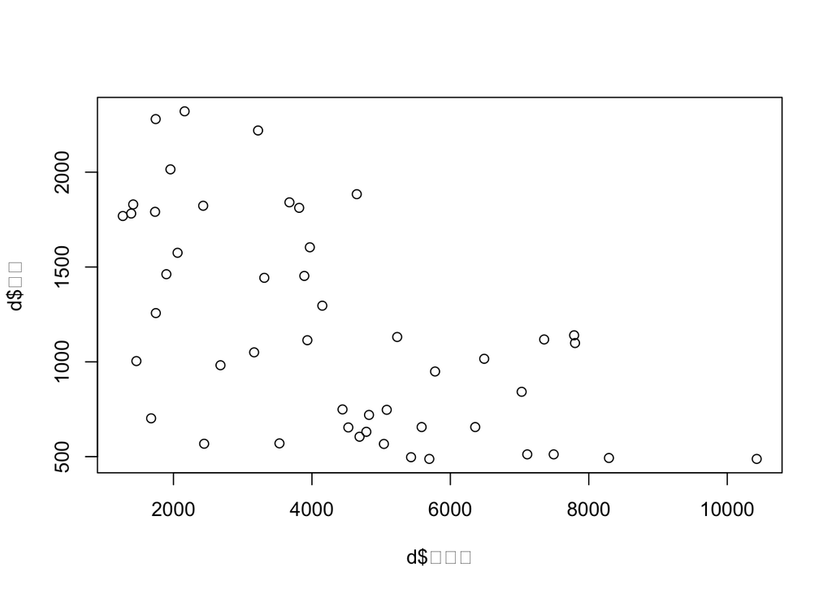

```r
# 散布図
plot(d$まぐろ,d$たい)
```

```r
# まぐろ、たい、あじ、さけ、ぶりの消費額の相関
d |>
  select(まぐろ,たい,あじ,さけ,ぶり) |>
  cor()
```

```
##            まぐろ       たい       あじ       さけ       ぶり
## まぐろ  1.0000000 -0.5879371 -0.5198516  0.2937395 -0.5024574
## たい   -0.5879371  1.0000000  0.5670789 -0.3328897  0.4906226
## あじ   -0.5198516  0.5670789  1.0000000 -0.3118548  0.6418709
## さけ    0.2937395 -0.3328897 -0.3118548  1.0000000 -0.2602345
## ぶり   -0.5024574  0.4906226  0.6418709 -0.2602345  1.0000000
```

```r
# 散布図に地名を加える
# ggplot(d, aes (x = まぐろ, y = たい)) +  geom_text(aes(label = 市), size = 4) +
#  xlab("まぐろ") + ylab ("たい") +
#  ggtitle("まぐろとたいの消費額") +
#  theme_gray()

# macの人は下のコマンド
# ggplot(d, aes (x = まぐろ, y = たい)) +  geom_text(aes(label = 市), size = 4, family = "HiraKakuPro-W3") +
#  xlab("まぐろ") + ylab ("たい") +
#  ggtitle("まぐろとたいの消費額") +
#  theme_gray(base_family = "HiraKakuPro-W3")
```